# Reanalise FPCC2

Lorena Pereira

3 de julho de 2019

# Replicação de um experimento

## Reanálise da Replicação de um Experimento

Reanalise feita a partir de novos dados gerados com base no artigo: Understanding the Factors that Impact the Popularity of GitHub Repositories - DOI: 10.1109/ICSME.2016.31

O script de extração dos dados pode ser encontrado nesse [notebook](https://github.com/Lorenaps/replicacao-pesquisa/blob/master/extracao_dados/search_github_api.ipynb), bem como a descrição dos dados.

Foi feito na linguagem Python utilizando a própria api do github e a biblioteca PyGithub. A extração final foi realizada do dia 7 de julho de 2019.

O artigo original descreve um estudo sobre a popularidade de sistemas de software no GitHub realizando 3 partes. A primeira é coletar os dados do github e fazer uma análise quantitativa a fim de responder algumas perguntas. Depois documenta-se 4 padrões de popularidade a partir da análise anterior e por fim realiza-se uma entrevista com 44 desenvolvedores sobre alguns aspectos identificados durante a execução do trabalho.

A atividade a ser replicada consiste na coleta dos dados através da api do github, análise quantitativa e conclusão considerando as questões de pesquisa do artigo original.

As replicação a seguir pretende responder a questão 2 das questões listadas no artigo original.

**Questão 02:** A popularidade se correlaciona com outras características de um repositório, como idade, número de contribuições, número de contribuintes e número de forks? Essa investigação é importante para verificar se há fatores que podem ser trabalhados para aumentar a popularidade de um projeto.

### Sobre a extração

A API do GitHub limita a utilização da ferramenta de pesquisa aos 1000 primeiros resultados, o que na prática se torna 1020 devido a páginação ser feita a cada 30 items, de forma que ou seriam 990 ou 1020, e no caso a página que contém o resultado 1000 permite a visualização até o resultado 1020.

Primeiro vamos a uma análise descritiva dos dados extraídos, e por fim a análise das informações necessárias para responder a questão 2.

## Import dos dados, exploração e análise descritiva

```r
options(scipen=999)

dados_full = read_csv("../dados/repositorios_update.csv")
glimpse(dados_full)
```

```
## Observations: 1,020
## Variables: 23
## $ id                <int> 28457823, 177736533, 11730342, 2126244, 1027...
## $ full_name         <chr> "freeCodeCamp/freeCodeCamp", "996icu/996.ICU...
## $ description       <chr> "The https://www.freeCodeCamp.org open sourc...
## $ owner_type        <chr> "Organization", "User", "Organization", "Org...
## $ owner_url         <chr> "https://api.github.com/users/freeCodeCamp",...
## $ owner_html_url    <chr> "https://github.com/freeCodeCamp", "https://...
## $ html_url          <chr> "https://github.com/freeCodeCamp/freeCodeCam...
## $ url               <chr> "https://api.github.com/repos/freeCodeCamp/f...
## $ fork              <chr> "False", "False", "False", "False", "False",...
## $ created_at        <dttm> 2014-12-24 17:49:19, 2019-03-26 07:31:14, 2...
## $ updated_at        <dttm> 2019-07-07 20:49:34, 2019-07-07 18:49:59, 2...
## $ size              <int> 117561, 59169, 27671, 143926, 143121, 362536...
## $ stargazers_count  <int> 303707, 246427, 143081, 134430, 132202, 1304...
## $ language          <chr> "JavaScript", "Rust", "JavaScript", "JavaScr...
## $ has_issues        <chr> "True", "False", "True", "True", "True", "Tr...
## $ has_wiki          <chr> "False", "False", "True", "False", "True", "...
## $ forks_count       <int> 22201, 21329, 20678, 65981, 24475, 75904, 31...
## $ forks             <int> 22201, 21329, 20678, 65981, 24475, 75904, 31...
## $ open_issues       <int> 1429, 16696, 313, 369, 757, 2631, 42, 19, 25...
## $ watchers          <int> 303707, 246427, 143081, 134430, 132202, 1304...
## $ timestamp_extract <int> 1562534114, 1562534114, 1562534114, 15625341...
## $ commits           <dbl> 23687, 2904, 3024, 18744, 11106, 59513, 5017...
## $ contributors      <chr> "3676", "579", "276", "1078", "1302", "2055"...
```

Olhando o atributo ‘contributors’ foi observado que para um registro existe um caractere especial ao invés de uma número.

```r
dados_full %>% filter(full_name == 'torvalds/linux') %>% select(contributors, html_url)
```

```
## # A tibble: 1 x 2
##   contributors html_url
##   <chr>        <chr>
## 1 ∞            https://github.com/torvalds/linux
```

Olhando a página do repositório do github é possível identificar que de fato aparece o símbolo extraído, mas também é possível identificar que a informação desejada aparece como 0 quando colocamos o mouse sobre o campo contributors. Logo substituiremos o valor aqui manualmente.

```r
dados_full = dados_full %>%
  mutate(contributors = replace(contributors, contributors == '∞', 0))

dados_full %>% filter(full_name == 'torvalds/linux') %>% select(contributors, html_url)
```

```
## # A tibble: 1 x 2
##   contributors html_url
##   <chr>        <chr>
## 1 0            https://github.com/torvalds/linux
```

Filtrando os campos desejados para análise

```r
dados = dados_full %>% select(full_name,
                              description,
                              owner_type,
                              created_at,
                              stargazers_count,
                              language,
                              forks,
                              timestamp_extract,
                              commits,
                              contributors) %>%
  mutate(timestamp_extract = as.POSIXct.numeric(timestamp_extract, origin = '1970-01-01')) %>%
  mutate(age_weeks = difftime(timestamp_extract, created_at, units = 'weeks')) %>%
  mutate(contributors = as.integer(contributors), commits = as.integer(commits), age_weeks = as.integer(age_weeks)) %>%
  mutate(language = replace(language, is.na(language), 'Não indicada'))
```

Verificando a existência de elementos duplicados

```r
duplicados = duplicated(dados, fromLast = TRUE)

which(duplicados)
```

```
## integer(0)
```

Descritivo dos dados:

```r
skim(dados)
```

```
## Skim summary statistics
##  n obs: 1020
##  n variables: 11
##
## ── Variable type:character ─────────────────────────────────────────────────────
##     variable missing complete    n min max empty n_unique
##  description       7     1013 1020   6 344     0     1013
##    full_name       0     1020 1020   4  75     0     1020
##     language       0     1020 1020   1  16     0       41
##   owner_type       0     1020 1020   4  12     0        2
##
## ── Variable type:integer ───────────────────────────────────────────────────────
##          variable missing complete    n     mean       sd    p0      p25
##         age_weeks       0     1020 1020   265.97   123.33     5   174
##           commits       0     1020 1020  6190.84 29111.21     1   457.75
##      contributors       0     1020 1020   248.82   520.3      0    41
##             forks       0     1020 1020  4175.93  5400.67   250  1411.5
##  stargazers_count       0     1020 1020 21771.25 18677.21 10967 13171.75
##      p50      p75   p100     hist
##    258     356.25    590 ▂▅▇▇▅▅▃▁
##   1280.5  4074.25 841892 ▇▁▁▁▁▁▁▁
##    106.5   256      8989 ▇▁▁▁▁▁▁▁
##   2619    4828.75  75904 ▇▁▁▁▁▁▁▁
##  16416.5 23101    303707 ▇▁▁▁▁▁▁▁
##
## ── Variable type:POSIXct ───────────────────────────────────────────────────────
##           variable missing complete    n        min        max     median
##         created_at       0     1020 1020 2008-03-10 2019-06-02 2014-07-22
##  timestamp_extract       0     1020 1020 2019-07-07 2019-07-07 2019-07-07
##  n_unique
##      1020
##        43
```

Boxplots

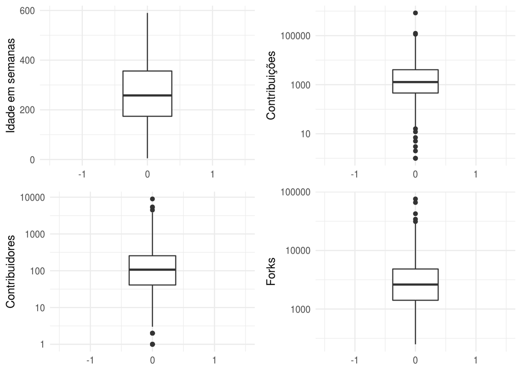

```r
p1 <- dados %>%
  ggplot(mapping = aes(y = age_weeks)) +
  # stat_boxplot(geom ='errorbar', fill = "#93A8AC") +
  geom_boxplot() +
  ylab("Idade em semanas") +
  scale_x_continuous(limits = c(-1.5, 1.5)) +
  theme_minimal()

p2 <- dados %>%
  ggplot(mapping = aes(y = commits)) +
  geom_boxplot() +
  ylab("Contribuições") +
  scale_y_log10() +
  scale_x_continuous(limits = c(-1.5, 1.5)) +
  theme_minimal()

p3 <- dados %>%
  ggplot(mapping = aes(y = contributors)) +
  geom_boxplot() +
  ylab("Contribuidores") +
  scale_y_log10() +
  scale_x_continuous(limits = c(-1.5, 1.5)) +
  theme_minimal()

p4 <- dados %>%
  ggplot(mapping = aes(y = forks)) +
  geom_boxplot() +
  ylab("Forks") +
  scale_y_log10() +
  scale_x_continuous(limits = c(-1.5, 1.5)) +
  theme_minimal()

g = grid.arrange(p1, p2, p3, p4, ncol=2)
```

```r
ggsave("figura1.pdf", g)
```

Quartis das estrelas recebidas

```r
q = dados$stargazers_count

quantile(q)
```

```
##        0%       25%       50%       75%      100%
##  10967.00  13171.75  16416.50  23101.00 303707.00
```

Quartis dos Commits

```r
q = dados$commits

quantile(q)
```

```
##        0%       25%       50%       75%      100%
##      1.00    457.75   1280.50   4074.25 841892.00
```

```r
q = dados$stargazers_count

quantile(q)
```

```
##        0%       25%       50%       75%      100%
##  10967.00  13171.75  16416.50  23101.00 303707.00
```

Quartis de forks

```r
t = dados$forks

quantile(t)
```

```
##       0%      25%      50%      75%     100%
##   250.00  1411.50  2619.00  4828.75 75904.00
```

Quartis da Idade

```r
q = dados$age_weeks

quantile(q)
```

```
##     0%    25%    50%    75%   100%
##   5.00 174.00 258.00 356.25 590.00
```

Distribuição das linguagens por repositório

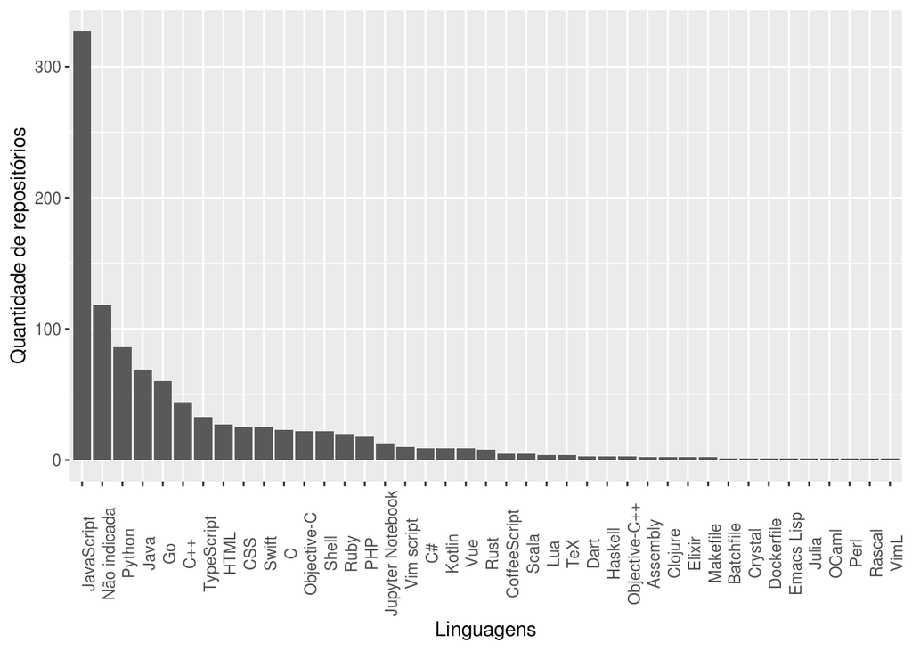

```r
dados %>%
  group_by(language) %>%
  summarise(n = n()) %>%
  arrange(desc(n)) %>%
  ggplot(mapping = aes(x = reorder(language, -n), y = n)) +
    geom_bar(position="dodge", stat="identity") +
    theme(axis.text.x = element_text(angle = 90)) +
    labs(x="Linguagens", y="Quantidade de repositórios")
```

```r
g <- dados %>%
  group_by(language) %>%
  summarise(n = n()) %>%
  top_n(5) %>%
  ggplot(mapping = aes(x = reorder(language, -n), y = n)) +
    geom_bar(position="dodge", stat="identity", fill = "#D8973C") +
    theme(axis.text.x = element_text(angle = 90)) +
    labs(x="Linguagens", y="Quantidade de Repositórios")
ggsave("figura2.pdf", g)
```

Linguagens com mais estrelas

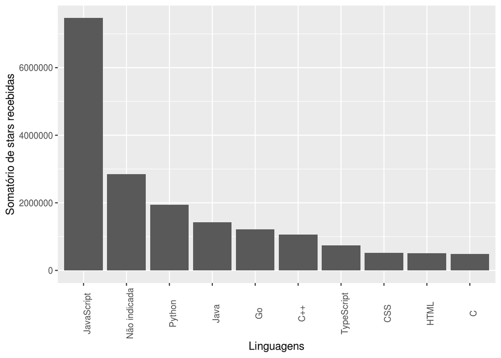

```r
dados %>%
  group_by(language) %>%
  summarise(n = sum(stargazers_count)) %>%
  top_n(10) %>%
  ggplot(mapping = aes(x = reorder(language, -n), y = n)) +
    geom_bar(position="dodge", stat="identity") +
    theme(axis.text.x = element_text(angle = 90)) +
    labs(x="Linguagens", y="Somatório de stars recebidas")
```

```r
  # colocar boxplot
```

Sumarizando correlações

```r
# ggggpairs(dados)
```

### Questão a ser respondida

A popularidade se correlaciona com outras características de um repositório, como idade, número de contribuições, número de contribuintes e número de forks?

#### Visualiação da correlação entre os campos

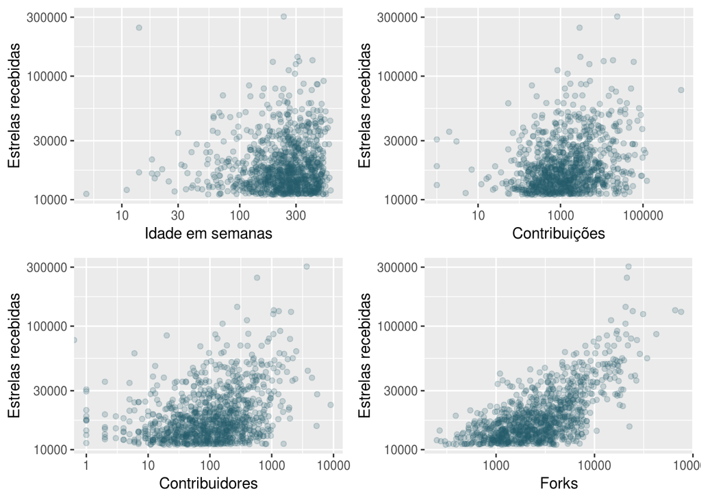

```r
p1 <- dados %>%
  ggplot(mapping = aes(x = age_weeks, y = stargazers_count)) +
  geom_jitter(alpha = .2, color = "#245D6A") +
  ylab("Estrelas recebidas") +
  xlab("Idade em semanas") +
  scale_y_log10() +
  scale_x_log10()

p2 <- dados %>%
  ggplot(mapping = aes(x = commits, y = stargazers_count)) +
  geom_jitter(alpha = .2, color = "#245D6A") +
  ylab("Estrelas recebidas") +
  xlab("Contribuições") +
  scale_y_log10() +
  scale_x_log10()

p3 <- dados %>%
  ggplot(mapping = aes(x = contributors, y = stargazers_count)) +
  geom_jitter(alpha = .2, color = "#245D6A") +
  ylab("Estrelas recebidas") +
  xlab("Contribuidores") +
  scale_y_log10() +
  scale_x_log10()

p4 <- dados %>%
  ggplot(mapping = aes(x = forks, y = stargazers_count)) +
  geom_jitter(alpha = .2, color = "#245D6A") +
  ylab("Estrelas recebidas") +
  xlab("Forks") +
  scale_y_log10() +
  scale_x_log10()


g = grid.arrange(p1, p2, p3, p4, ncol=2)
```

```r
ggsave("figura3.pdf", g)
```

#### Medindo a correlação e o intevalo de confiança

Estrelas X Idade do repositório

**Resultados do artigo original: stars x age - Spearman’s Rank correlation (rho = 0,0757 p < 0.001)**

```r
dados %>%
  summarise(pearson = cor(stargazers_count, age_weeks, method = "pearson"),
            spearman = cor(stargazers_count, age_weeks, method = "spearman"),
            kendall = cor(stargazers_count, age_weeks, method = "kendall"), )
```

```
## # A tibble: 1 x 3
##   pearson spearman kendall
##     <dbl>    <dbl>   <dbl>
## 1  0.0322   0.0547  0.0367
```

Estrelas X Commits do repositório

**Resultados do artigo original: stars x commits - Spearman’s Rank correlation (rho = 0,249 p < 0.001)**

```r
dados %>%
  summarise(pearson = cor(stargazers_count, commits, method = "pearson"),
            spearman = cor(stargazers_count, commits, method = "spearman"),
            kendall = cor(stargazers_count, commits, method = "kendall"), )
```

```
## # A tibble: 1 x 3
##   pearson spearman kendall
##     <dbl>    <dbl>   <dbl>
## 1   0.151    0.238   0.160
```

Estrelas X Contributors

**Resultados do artigo original: stars x contributors - Spearman’s Rank correlation (rho = 0,341 p < 0.001)**

```r
dados %>%
  summarise(pearson = cor(stargazers_count, contributors, method = "pearson"),
            spearman = cor(stargazers_count, contributors, method = "spearman"),
            kendall = cor(stargazers_count, contributors, method = "kendall"), )
```

```
## # A tibble: 1 x 3
##   pearson spearman kendall
##     <dbl>    <dbl>   <dbl>
## 1   0.317    0.312   0.213
```

Estrelas X Forks

**Resultados do artigo original: stars x forks - Spearman’s Rank correlation (rho = 0,549 p < 0.001)**

```r
dados %>%
  summarise(pearson = cor(stargazers_count, forks, method = "pearson"),
            spearman = cor(stargazers_count, forks, method = "spearman"),
            kendall = cor(stargazers_count, forks, method = "kendall"))
```

```
## # A tibble: 1 x 3
##   pearson spearman kendall
##     <dbl>    <dbl>   <dbl>
## 1   0.677    0.593   0.424
```

**Outra forma de medir a correlação juntamente ao pvalor**

```r
cor.test(~ stargazers_count + forks, data=dados, method = 'spearman', continuity = FALSE, conf.level = 0.95)
```

```
##
##  Spearman's rank correlation rho
##
## data:  stargazers_count and forks
## S = 71971000, p-value < 0.00000000000000022
## alternative hypothesis: true rho is not equal to 0
## sample estimates:
##       rho
## 0.5930795
```

```r
cor.test(~ stargazers_count + age_weeks, data=dados, method = 'spearman', continuity = FALSE, conf.level = 0.95)
```

```
##
##  Spearman's rank correlation rho
##
## data:  stargazers_count and age_weeks
## S = 167200000, p-value = 0.08088
## alternative hypothesis: true rho is not equal to 0
## sample estimates:
##        rho
## 0.05468256
```

```r
cor.test(~ stargazers_count + commits, data=dados, method = 'spearman', continuity = FALSE, conf.level = 0.95)
```

```
##
##  Spearman's rank correlation rho
##
## data:  stargazers_count and commits
## S = 134860000, p-value = 0.00000000000001505
## alternative hypothesis: true rho is not equal to 0
## sample estimates:
##       rho
## 0.2375301
```

```r
cor.test(~ stargazers_count + contributors, data=dados, method = 'spearman', continuity = FALSE, conf.level = 0.95)
```

```
##
##  Spearman's rank correlation rho
##
## data:  stargazers_count and contributors
## S = 121630000, p-value < 0.00000000000000022
## alternative hypothesis: true rho is not equal to 0
## sample estimates:
##       rho
## 0.3123368
```

#### Intervalo de confiança

Estrelas X Idade do repositório

```r
function_correlacao = function(df, i){
    theta_c_correlacao = df %>%
        slice(i) %>%
        summarise(correlacao = cor(stargazers_count, age_weeks, method = "spearm")) %>%
        pull(correlacao)

    return(theta_c_correlacao)
}

booted_cor <- boot(data = dados,
               statistic = function_correlacao,
               R = 4000)

cor = tidy(booted_cor,
          conf.level = .95,
          conf.method = "basic",
          conf.int = TRUE)
cor
```

```
## # A tibble: 1 x 5
##   statistic      bias std.error conf.low conf.high
##       <dbl>     <dbl>     <dbl>    <dbl>     <dbl>
## 1    0.0547 -0.000461    0.0311 -0.00444     0.118
```

Estrelas X Commits

```r
function_correlacao = function(df, i){
    theta_c_correlacao = df %>%
        slice(i) %>%
        summarise(correlacao = cor(stargazers_count, commits, method = "spearm")) %>%
        pull(correlacao)

    return(theta_c_correlacao)
}

booted_cor <- boot(data = dados,
               statistic = function_correlacao,
               R = 4000)

cor = tidy(booted_cor,
          conf.level = .95,
          conf.method = "basic",
          conf.int = TRUE)
cor
```

```
## # A tibble: 1 x 5
##   statistic       bias std.error conf.low conf.high
##       <dbl>      <dbl>     <dbl>    <dbl>     <dbl>
## 1     0.238 -0.0000854    0.0306    0.178     0.297
```

Estrelas X Contributors

```r
function_correlacao = function(df, i){
    theta_c_correlacao = df %>%
        slice(i) %>%
        summarise(correlacao = cor(stargazers_count, contributors, method = "spearm")) %>%
        pull(correlacao)

    return(theta_c_correlacao)
}

booted_cor <- boot(data = dados,
               statistic = function_correlacao,
               R = 4000)

cor = tidy(booted_cor,
          conf.level = .95,
          conf.method = "basic",
          conf.int = TRUE)
cor
```

```
## # A tibble: 1 x 5
##   statistic      bias std.error conf.low conf.high
##       <dbl>     <dbl>     <dbl>    <dbl>     <dbl>
## 1     0.312 -0.000684    0.0295    0.254     0.372
```

Estrelas X Forks

```r
function_correlacao = function(df, i){
    theta_c_correlacao = df %>%
        slice(i) %>%
        summarise(correlacao = cor(stargazers_count, forks, method = "spearm")) %>%
        pull(correlacao)

    return(theta_c_correlacao)
}

booted_cor <- boot(data = dados,
               statistic = function_correlacao,
               R = 4000)

cor = tidy(booted_cor,
          conf.level = .95,
          conf.method = "basic",
          conf.int = TRUE)
cor
```

```
## # A tibble: 1 x 5
##   statistic      bias std.error conf.low conf.high
##       <dbl>     <dbl>     <dbl>    <dbl>     <dbl>
## 1     0.593 -0.000469    0.0226    0.551     0.639
```

Para a questão 2 foi possível encontrar um comportamente semelhante ao relatado n artigo anterior porém o nova analise permitiu um npivel de detalhamento maior por apresentar o intervalo de confiança

- Análise dos dados